# Worldwide Trends and Effort During the Coronavirus Pandemic

Kaitlyn Won  
CMSC320 Summer 2020  
Published July 21, 2020

## 1. Introduction

During the past 4 months of quarantine, our news feeds have been flooded with daily media coverage of the coronavirus pandemic and its statistics. As we progress through the summer months, there has been an increasing interest in what the road to recovery looks like in the months ahead and in the measures that have been adopted thus far. We hear of new policies being implemented everyday during these "unprecedented times," as many have phrased to describe the crisis. In some countries, there has been significant reductions in cases due to well-adopted measurements. On the other hand, as the cases in the US continues to rise, the nation is on track as the epicenter of the pandemic, and there is an abundance of news outlets discussing the relatively minimal efforts and slow progress made by the US government.  
Since there are plenty of public data sets for the pandemic, there are several questions I find to be worth exploring. I will begin with the question most relevant to the current days of the pandemic: Is the number of cases declining during the summer months? How has the death rate changed? Then, I will move onto analyzing effort; that is, exploring the question, how much effort have countries put in as a countermeasure against the spread of the pandemic?  
For analyzing effort, I want to create a self-defined measure of **effort** because the available data sets mostly concern the effects of the coronavirus compared to the efforts. For instance, the Bureau of Labor Statistics measured effects using the current population [survey](https://www.bls.gov/covid19/measuring-the-effects-of-the-coronavirus-covid-19-pandemic-using-the-current-population-survey.htm). I will utilize this self-defined measurement to visualize and thereby view the relative efforts made by countries through quantitative lens.  
At the end, I hope to have provided insight to the public of the bigger picture in the global trends of and effort during the coronavirus pandemic.

### 1.1 Tools

```python
import pandas as pd
import numpy as np
from datetime import datetime
import warnings
import seaborn as sns
import matplotlib.pyplot as plt
from statsmodels.formula.api import ols
from scipy import stats
```

## 2. Data Collection

First, I started by searching the Internet for official data sets. I will be using a [data set](https://ourworldindata.org/coronavirus-source-data) from a scientific online publication called Our World in Data (OWID). The OWID data consists of a variety of coronavirus statistics, and the ACAPS [data set](https://www.acaps.org/covid19-government-measures-dataset) holds a combination of qualitative and quantitative information on governmental measures, of which I am interested in the initial policy implementation dates. For both data sets, extracting the data and converting them into data frames was fairly easy because of they were stored in well-structured csv and excel form, respectively.

```python
owid = pd.read_csv('owid-covid-data.csv')
acaps = pd.read_excel('acaps_covid19_government_measures_dataset_0.xlsx', sheet_name='Database')
```

### 2.1 OWID Data

```python
owid.head(5)
```

|  | iso_code | continent | location | date | total_cases | new_cases | total_deaths | new_deaths | total_cases_per_million | new_cases_per_million | ... | aged_70_older | gdp_per_capita | extreme_poverty | cvd_death_rate | diabetes_prevalence | female_smokers | male_smokers | handwashing_facilities | hospital_beds_per_thousand | life_expectancy |
| --- | --- | --- | --- | --- | --- | --- | --- | --- | --- | --- | --- | --- | --- | --- | --- | --- | --- | --- | --- | --- | --- |
| 0 | AFG | Asia | Afghanistan | 2019-12-31 | 0.0 | 0.0 | 0.0 | 0.0 | 0.0 | 0.0 | ... | 1.337 | 1803.987 | NaN | 597.029 | 9.59 | NaN | NaN | 37.746 | 0.5 | 64.83 |
| 1 | AFG | Asia | Afghanistan | 2020-01-01 | 0.0 | 0.0 | 0.0 | 0.0 | 0.0 | 0.0 | ... | 1.337 | 1803.987 | NaN | 597.029 | 9.59 | NaN | NaN | 37.746 | 0.5 | 64.83 |
| 2 | AFG | Asia | Afghanistan | 2020-01-02 | 0.0 | 0.0 | 0.0 | 0.0 | 0.0 | 0.0 | ... | 1.337 | 1803.987 | NaN | 597.029 | 9.59 | NaN | NaN | 37.746 | 0.5 | 64.83 |
| 3 | AFG | Asia | Afghanistan | 2020-01-03 | 0.0 | 0.0 | 0.0 | 0.0 | 0.0 | 0.0 | ... | 1.337 | 1803.987 | NaN | 597.029 | 9.59 | NaN | NaN | 37.746 | 0.5 | 64.83 |
| 4 | AFG | Asia | Afghanistan | 2020-01-04 | 0.0 | 0.0 | 0.0 | 0.0 | 0.0 | 0.0 | ... | 1.337 | 1803.987 | NaN | 597.029 | 9.59 | NaN | NaN | 37.746 | 0.5 | 64.83 |

5 rows × 34 columns

The **stringency index** is one the columns in the OWID data above (not printed), and it is an existing measure that quantifies the strictness of a country's coronavirus policies on an ordinal scale. Note that the stringency index does not serve to evaluate the effort of a country's response to the pandemic. The measure is calculated by considering the several indicators, which include the following, and further details can be found on the OWID GitHub repository [codebook](https://github.com/OxCGRT/covid-policy-tracker/blob/master/documentation/codebook.md):

- C – containment and cloure policies
- E – economic policies
- H – health system policies
- M – miscellaneous policies

### 2.2 ACAPS Data

```python
acaps.head(5)
```

|  | ID | COUNTRY | ISO | ADMIN_LEVEL_NAME | PCODE | REGION | LOG_TYPE | CATEGORY | MEASURE | TARGETED_POP_GROUP | COMMENTS | NON_COMPLIANCE | DATE_IMPLEMENTED | SOURCE | SOURCE_TYPE | LINK | ENTRY_DATE | Alternative source |
| --- | --- | --- | --- | --- | --- | --- | --- | --- | --- | --- | --- | --- | --- | --- | --- | --- | --- | --- |
| 0 | 1 | Afghanistan | AFG | NaN | NaN | Asia | Introduction / extension of measures | Public health measures | Health screenings in airports and border cross... | No | NaN | NaN | 2020-02-12 | Ministry of Health | Government | https://moph.gov.af/en/moph-held-emergency-mee... | 2020-03-14 | NaN |
| 1 | 2 | Afghanistan | AFG | Kabul | NaN | Asia | Introduction / extension of measures | Public health measures | Isolation and quarantine policies | No | NaN | NaN | 2020-02-12 | Ministry of Health | Government | https://moph.gov.af/en/moph-held-emergency-mee... | 2020-03-14 | NaN |
| 2 | 3 | Afghanistan | AFG | NaN | NaN | Asia | Introduction / extension of measures | Public health measures | Awareness campaigns | No | NaN | NaN | 2020-02-12 | Ministry of Health | Government | https://moph.gov.af/en/moph-held-emergency-mee... | 2020-03-14 | NaN |
| 3 | 4 | Afghanistan | AFG | NaN | NaN | Asia | Introduction / extension of measures | Governance and socio-economic measures | Emergency administrative structures activated ... | No | NaN | NaN | 2020-02-12 | Ministry of Health | Government | https://moph.gov.af/en/moph-held-emergency-mee... | 2020-03-14 | NaN |
| 4 | 5 | Afghanistan | AFG | NaN | NaN | Asia | Introduction / extension of measures | Social distancing | Limit public gatherings | No | Nevruz festival cancelled | NaN | 2020-03-12 | AA | Media | https://www.aa.com.tr/en/asia-pacific/coronavi... | 2020-03-14 | NaN |

## 3. Data Processing

Now that I have converted the data sets into individual data frames, it is time to perform some processing before combining the data sets into a single data frame to analyze.

### 3.1 Implementation Date of First Policy

From the ACAPS data, I am interested in extracting the implementation date of the first policy of each country, which indicates when a country started taking measures against the coronavirus. The data set has information on all of the major policies implemented per country, and these are listed in chronological order. Hence, filtering the first policies is simple.

```python
# Group by ISO and insert first row of each into a new data frame.
acaps_first_dates = acaps.groupby('ISO').first()
```

### 3.2 Filtering Data

Now, I will drop some of the columns of the OWID data frame because they are repetitive aggregations of other columns or are not directly relevant to measuring effort. Similarly in the ACAPS data frame, I am only interested in the country and implementation dates of the first policies because I am focusing on "when" a country began to take action over the "what," which the stringency index already covers.

```python
owid.drop(owid.columns[np.r_[8:12,14:18,22:25,26,28:34]], axis=1, inplace=True)
acaps_first_dates = acaps_first_dates[['COUNTRY','DATE_IMPLEMENTED']]
```

Because records preceding the first coronavirus case are not relevant to the analysis, I will remove these rows from the OWID data frame as well.

```python
owid = owid[owid.total_cases > 0]
```

### 3.3 Data Column Types

Since dates are sometimes stored as strings, I will check that the ACAPS first policy implementation date and OWID entry dates are Timestamp objects and convert as necessary.

```python
# Random row value chosen to output type
print(type(acaps_first_dates.at['AFG', 'DATE_IMPLEMENTED']))
print(type(owid.at[56, 'date']))
```

```
<class 'pandas._libs.tslibs.timestamps.Timestamp'>
<class 'str'>
```

```python
for i, v in owid.iterrows():
    s = owid.at[i, 'date']
    owid.at[i, 'date'] = datetime.strptime(s, '%Y-%m-%d')
    owid.at[i, 'date'] = pd.to_datetime(s, format='%Y-%m-%d')
```

```python
for i, v in acaps_first_dates.iterrows():
    s = acaps_first_dates.at[i, 'DATE_IMPLEMENTED']
    acaps_first_dates.at[i, 'DATE_IMPLEMENTED'] = pd.to_datetime(s, format='%Y-%m-%d')
```

### 3.4 Combining Data

Let's combine the data columns into a single data frame. First, the indicies and overlapping columns (ISO code and country) should be formatted in a uniform way.

```python
# Set acaps_first_dates index as a column
acaps_first_dates['ISO'] = acaps_first_dates.index
acaps_first_dates.reset_index(inplace = True, drop = True)

# Rename acaps_first_dates columns to follow naming conventions of OWID data frame
acaps_first_dates.columns = ['location', 'date_implemented', 'iso_code']
```

Since the two data sets are from different sources, I will check if they cover the same countries. As shown directly below, the two data frames do not account for the same number of countries in the world. Hence, there will be missing data for first policy implementation dates for some countries.

```python
print(len(owid.iso_code.value_counts()))
print(len(acaps_first_dates.iso_code.value_counts()))
```

```
210
193
```

```python
# Combined data frame created, based on the OWID data
df = owid
df['first_policy_date'] = ' '

# ACAPS first policy implementation dates added to corresponding columns of combined dataframe
for i, r in df.iterrows():
    if r.iso_code in acaps_first_dates.iso_code.unique():
        df.at[i, 'first_policy_date'] = acaps_first_dates[acaps_first_dates.iso_code == r.iso_code].date_implemented.array[0].date()
    else:
        df.at[i, 'first_policy_date'] = np.nan
```

Since the OWID data provides global information in addition to those pertaining individual countries, I split the data frame to filter out the global information. This final step of data processing will facilitate comparisons to total values.

```python
df = df[((df.location != 'International') & (df.location != 'World'))]

# Reset index
df.reset_index(drop=True)
```

|  | iso_code | continent | location | date | total_cases | new_cases | total_deaths | new_deaths | total_tests | new_tests | tests_units | stringency_index | population | population_density | gdp_per_capita | cvd_death_rate | first_policy_date |
| --- | --- | --- | --- | --- | --- | --- | --- | --- | --- | --- | --- | --- | --- | --- | --- | --- | --- |
| 0 | AFG | Asia | Afghanistan | 2020-02-25 00:00:00 | 1.0 | 1.0 | 0.0 | 0.0 | NaN | NaN | NaN | 8.33 | 38928341.0 | 54.422 | 1803.987 | 597.029 | 2020-02-12 |
| 1 | AFG | Asia | Afghanistan | 2020-02-26 00:00:00 | 1.0 | 0.0 | 0.0 | 0.0 | NaN | NaN | NaN | 8.33 | 38928341.0 | 54.422 | 1803.987 | 597.029 | 2020-02-12 |
| 2 | AFG | Asia | Afghanistan | 2020-02-27 00:00:00 | 1.0 | 0.0 | 0.0 | 0.0 | NaN | NaN | NaN | 8.33 | 38928341.0 | 54.422 | 1803.987 | 597.029 | 2020-02-12 |
| 3 | AFG | Asia | Afghanistan | 2020-02-28 00:00:00 | 1.0 | 0.0 | 0.0 | 0.0 | NaN | NaN | NaN | 8.33 | 38928341.0 | 54.422 | 1803.987 | 597.029 | 2020-02-12 |
| 4 | AFG | Asia | Afghanistan | 2020-02-29 00:00:00 | 1.0 | 0.0 | 0.0 | 0.0 | NaN | NaN | NaN | 8.33 | 38928341.0 | 54.422 | 1803.987 | 597.029 | 2020-02-12 |
| ... | ... | ... | ... | ... | ... | ... | ... | ... | ... | ... | ... | ... | ... | ... | ... | ... | ... |
| 26669 | ZWE | Africa | Zimbabwe | 2020-07-10 00:00:00 | 926.0 | 41.0 | 12.0 | 3.0 | 36005.0 | 659.0 | tests performed | NaN | 14862927.0 | 42.729 | 1899.775 | 307.846 | 2020-03-12 |
| 26670 | ZWE | Africa | Zimbabwe | 2020-07-11 00:00:00 | 942.0 | 16.0 | 13.0 | 1.0 | NaN | NaN | NaN | NaN | 14862927.0 | 42.729 | 1899.775 | 307.846 | 2020-03-12 |
| 26671 | ZWE | Africa | Zimbabwe | 2020-07-12 00:00:00 | 982.0 | 40.0 | 18.0 | 5.0 | NaN | NaN | NaN | NaN | 14862927.0 | 42.729 | 1899.775 | 307.846 | 2020-03-12 |
| 26672 | ZWE | Africa | Zimbabwe | 2020-07-13 00:00:00 | 985.0 | 3.0 | 18.0 | 0.0 | NaN | NaN | NaN | NaN | 14862927.0 | 42.729 | 1899.775 | 307.846 | 2020-03-12 |
| 26673 | ZWE | Africa | Zimbabwe | 2020-07-14 00:00:00 | 1034.0 | 49.0 | 19.0 | 1.0 | NaN | NaN | NaN | NaN | 14862927.0 | 42.729 | 1899.775 | 307.846 | 2020-03-12 |

26674 rows × 17 columns

## 4. Is the number of cases declining during the summer?

There have been many individuals speculating and hopeful for the slowing of the virus' spread during the summer season. However, health officials and researchers have expressed doubt on a decline. Notably, the NIH director Dr. Francis Collins has released a [statement](https://directorsblog.nih.gov/2020/06/02/will-warm-weather-slow-spread-of-novel-coronavirus/) about the health community's doubt of seasonal decline of the coronavirus. First, I will analyze the number of cases beginning in the spring. Then, since we are now a month into the summer season, I will analyze the trend of coronavirus cases starting from June 21, 2020, which is the first day of summer. Last of all, I will compare the summer rate thus far to the spring trend.

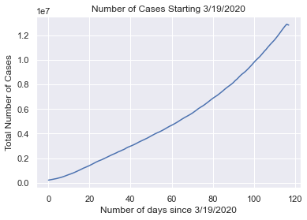

```python
# Timestamp objects of esssential dates to dividing the date frame between spring and summer seasons.
first_day_spring = '2020-3-19'
first_day_spring = pd.to_datetime(first_day_spring, format='%Y-%m-%d')
last_day_spring = '2020-6-20'
last_day_spring = pd.to_datetime(last_day_spring, format='%Y-%m-%d')
first_day_summer = '2020-6-21'
first_day_summer = pd.to_datetime(first_day_summer, format='%Y-%m-%d')
most_recent_day = '2020-7-14'
most_recent_day = pd.to_datetime(most_recent_day, format='%Y-%m-%d')

summer_and_spring_df = df[(df.date >= first_day_spring) & (df.date <= most_recent_day)]
summer_and_spring_cases = pd.DataFrame(summer_and_spring_df.groupby('date').total_cases.sum())
summer_and_spring_cases.columns = ['total_cases']
summer_and_spring_cases['date'] = summer_and_spring_cases.index
summer_and_spring_cases['days_since_200319'] = range(0, len(summer_and_spring_cases.total_cases))

# Figure for spring and summer
sns.set(style="darkgrid")
ax = sns.lineplot(x="days_since_200319", y="total_cases", data=summer_and_spring_cases)
ax.set_title('Number of Cases Starting 3/19/2020')
ax.set_xlabel('Number of days since 3/19/2020')
# h is just a placeholder variable to stop text from being outputted when the below configurations are made
h = ax.set_ylabel('Total Number of Cases')
```

It is clear that there has been a significant increase in number of cases since the beginning of spring. The total appears to decrease in the recent days, but it is too early to tell whether or not this is a permanent trajectory. Let's continue analyzing the seasons individually to note any difference in the trend of number of cases.

```python
# Parts of dataframe filtered for seasons
spring_df = df[(df.date >= first_day_spring) & (df.date <= last_day_spring)]
summer_df = df[(df.date >= first_day_summer) & (df.date <= most_recent_day)]

# Total number of cases per day for each season
spring_cases = pd.DataFrame(spring_df.groupby('date').total_cases.sum())
summer_cases = pd.DataFrame(summer_df.groupby('date').total_cases.sum())
spring_cases.columns = ['total_cases']
summer_cases.columns = ['total_cases']
spring_cases['days_into_spring'] = range(0, len(spring_cases.total_cases))
summer_cases['days_into_summer'] = range(0, len(summer_cases.total_cases))
```

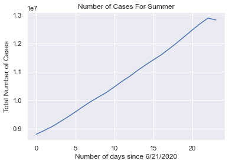

```python
# Figure for summer
sns.set(style="darkgrid")
ax = sns.lineplot(x="days_into_summer", y="total_cases", data=summer_cases)
ax.set_title('Number of Cases For Summer')
ax.set_xlabel('Number of days since 6/21/2020')
h = ax.set_ylabel('Total Number of Cases')
```

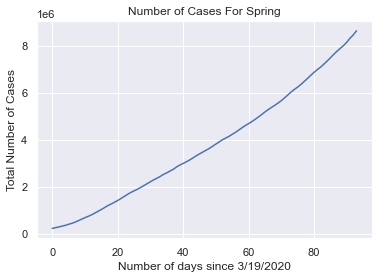

```python
# Figure for spring
sns.set(style="darkgrid")
ax = sns.lineplot(x="days_into_spring", y="total_cases", data=spring_cases)
ax.set_title('Number of Cases For Spring')
ax.set_xlabel('Number of days since 3/19/2020')
h = ax.set_ylabel('Total Number of Cases')
```

From the figures alone, it is a bit difficult to understand exactly how different the trend has become. To view this in a quantitative manner, I will utilize [OLS regression](https://www.datarobot.com/blog/ordinary-least-squares-in-python/).

```python
reg_spring = ols(formula='total_cases ~ days_into_spring', data=spring_cases).fit()
reg_spring.summary()
```

OLS Regression Results

| Dep. Variable: | total_cases | R-squared: | 0.988 |
| --- | --- | --- | --- |
| Model: | OLS | Adj. R-squared: | 0.988 |
| Method: | Least Squares | F-statistic: | 7840. |
| Date: | Tue, 21 Jul 2020 | Prob (F-statistic): | 7.66e-91 |
| Time: | 17:05:03 | Log-Likelihood: | -1305.7 |
| No. Observations: | 94 | AIC: | 2615. |
| Df Residuals: | 92 | BIC: | 2620. |
| Df Model: | 1 |  |  |
| Covariance Type: | nonrobust |  |  |

|  | coef | std err | t | P>\|t\| | [0.025 | 0.975] |
| --- | --- | --- | --- | --- | --- | --- |
| Intercept | -3.652e+05 | 5.39e+04 | -6.770 | 0.000 | -4.72e+05 | -2.58e+05 |
| days_into_spring | 8.871e+04 | 1001.909 | 88.543 | 0.000 | 8.67e+04 | 9.07e+04 |

| Omnibus: | 12.485 | Durbin-Watson: | 0.012 |
| --- | --- | --- | --- |
| Prob(Omnibus): | 0.002 | Jarque-Bera (JB): | 14.145 |
| Skew: | 0.950 | Prob(JB): | 0.000848 |
| Kurtosis: | 3.034 | Cond. No. | 107. |

Warnings:  
[1] Standard Errors assume that the covariance matrix of the errors is correctly specified.

```python
reg_summer = ols(formula='total_cases ~ days_into_summer', data=summer_cases).fit()
reg_summer.summary()
```

OLS Regression Results

| Dep. Variable: | total_cases | R-squared: | 0.997 |
| --- | --- | --- | --- |
| Model: | OLS | Adj. R-squared: | 0.997 |
| Method: | Least Squares | F-statistic: | 8542. |
| Date: | Tue, 21 Jul 2020 | Prob (F-statistic): | 5.41e-30 |
| Time: | 17:05:03 | Log-Likelihood: | -300.13 |
| No. Observations: | 24 | AIC: | 604.3 |
| Df Residuals: | 22 | BIC: | 606.6 |
| Df Model: | 1 |  |  |
| Covariance Type: | nonrobust |  |  |

|  | coef | std err | t | P>\|t\| | [0.025 | 0.975] |
| --- | --- | --- | --- | --- | --- | --- |
| Intercept | 8.669e+06 | 2.7e+04 | 321.263 | 0.000 | 8.61e+06 | 8.72e+06 |
| days_into_summer | 1.858e+05 | 2010.297 | 92.423 | 0.000 | 1.82e+05 | 1.9e+05 |

| Omnibus: | 2.621 | Durbin-Watson: | 0.767 |
| --- | --- | --- | --- |
| Prob(Omnibus): | 0.270 | Jarque-Bera (JB): | 2.079 |
| Skew: | 0.706 | Prob(JB): | 0.354 |
| Kurtosis: | 2.706 | Cond. No. | 26.1 |

Warnings:  
[1] Standard Errors assume that the covariance matrix of the errors is correctly specified.

Based on the OLS regression result, it appears that there is an increase of 1.858e+05 cases per day in the summer (thus far) and 8.871e+04 cases during the spring. Moreover, R-squared is high for both seasons, further strenghtening the regressions. Hence, there has been an increase in coronavirus cases during the summer thus far, not a decline.

## 5. How Has the Coronavirus Death Rate Changed?

Now, let's look at trends in the coronavirus death rate by groupings. I will group the data based on geographical locations, so I will look at how the death rate changes per day for each continent and then look at the global trend.

### 5.1 By Continent

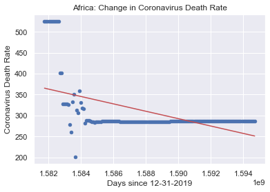

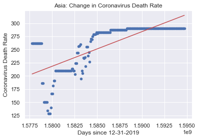

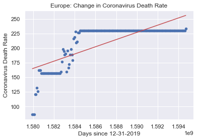

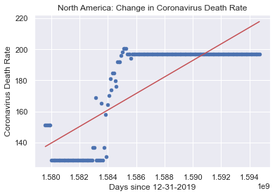

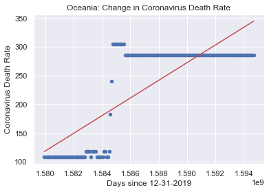

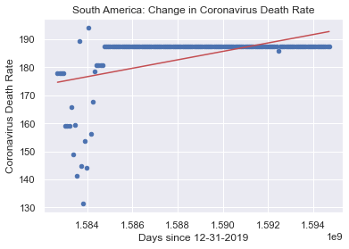

```python
%%capture output --no-display
# Above supresses color argument warning for figure coloration below. This comment is underneath because the
# supression only works if the line is the first in the cell.

df['date_epoch'] = df['date'].apply(lambda x: datetime.timestamp(x))

cont_covid_dr = {}

for c, v in df.groupby('continent'):
    cont = pd.DataFrame(v.groupby('date_epoch').cvd_death_rate.mean())
    cont['date_epoch'] = cont.index
    cont.plot(kind='scatter', x='date_epoch', y='cvd_death_rate')
    m, b = np.polyfit(cont.date_epoch, cont.cvd_death_rate, 1)
    cont_covid_dr[c] = m
    plt.plot(cont.date_epoch, m*cont.date_epoch + b, color='r')
    plt.title(c + ": Change in Coronavirus Death Rate")
    plt.xlabel('Days since 12-31-2019')
    plt.ylabel('Coronavirus Death Rate')
```

```python
# Linear regression slopes (average change in coronavirus death rate per day)
cont_covid_dr = pd.Series(cont_covid_dr)
cont_covid_dr = cont_covid_dr.sort_values()
cont_covid_dr
```

```
Africa          -0.000009
South America    0.000002
North America    0.000005
Europe           0.000006
Asia             0.000007
Oceania          0.000015
dtype: float64
```

It appears that when grouped by continent, Oceania is leading in the increase of coronavirus death rates. A common characteristic of all of the continents is that the rate has remained consistent during the recent months; the drastic changes appear to have happened in early spring.

### 5.2 World Trend

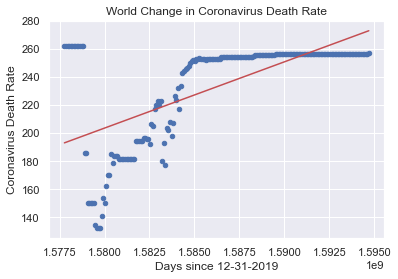

```python
%%capture output --no-display

rate_per_day = pd.DataFrame(df.groupby('date_epoch').cvd_death_rate.mean())
rate_per_day['date_epoch'] = rate_per_day.index
rate_per_day.plot(kind='scatter', x='date_epoch', y='cvd_death_rate')
m, b = np.polyfit(rate_per_day.date_epoch, rate_per_day.cvd_death_rate, 1)
plt.plot(rate_per_day.date_epoch, m*rate_per_day.date_epoch + b, color='r')
plt.title("World Change in Coronavirus Death Rate")
plt.xlabel('Days since 12-31-2019')
h = plt.ylabel('Coronavirus Death Rate')
```

The patterns from each continent are apparent in the global trend of the coronavirus death rate, notably the increase in death rate during the spring and the plateau of the rate in the current days. An interesting observation unique to the world trend is that the death rate today is becoming closser to the initial rates that had been recorded.  
Now that I have gained insight into the patterns of the raw counts, the next step is to conduct further analysis on the the impact of these counts, and that will be done through the calculation of effort.

## 6. Calculating Effort

With thes raw numbers and dates from the data frame, I want to measure governmental effort during the pandemic, which is going to be categorized into two types of effort: the policy enforcement effort and use of resources effort. Both efforts are measured as a ranking, or in other words, effort that is based on relative performance.

### 6.1 Policy Enforcement Effort

Policy enforcement effort will be calculated through ranking based on policy effectiveness. I am going to do so based on the linear trend in increase per day of the population percentages of cases and deaths for each country following the date of their first policy implementation. We cannot rank solely by the case and death counts because the raw numbers themselves do not provide the context, for there is a directly proportional relationship between raw quantity and population size. Hence, it is the percentages that provide insight.

```python
# Filter out SettingWithCopyWarning that appears when summing data frame columns
warnings.filterwarnings('ignore')

df['cases_and_deaths_pct'] = ((df['total_cases'] + df['total_deaths']) / df['population']) * 100
post_data = df[(not df.date is np.nan) & (df.date >= df.first_policy_date)]

policy_effort = pd.DataFrame(post_data.iso_code.unique(), columns=['iso_code'])
policy_effort['trends'] = np.float64(0) # placeholder

# Dates were transformed into epoch time because trend can only be found between scalar values
for c, v in policy_effort.iterrows():
    c_df = post_data[post_data.iso_code == v.iso_code]
    c_df['date_epoch'] = c_df['date'].apply(lambda x: datetime.timestamp(x))
    m, b = np.polyfit(c_df.date_epoch, c_df.cases_and_deaths_pct, 1)
    policy_effort.at[c, 'trends'] = m

policy_effort['ranking'] = policy_effort.trends.rank()

# Order by rank
policy_effort = policy_effort.sort_values('ranking')
```

```python
policy_effort.head(10)
```

|  | iso_code | trends | ranking |
| --- | --- | --- | --- |
| 125 | PNG | 1.114943e-11 | 1.0 |
| 88 | LAO | 1.165853e-11 | 2.0 |
| 176 | VNM | 2.385797e-11 | 3.0 |
| 27 | KHM | 3.367848e-11 | 4.0 |
| 112 | MMR | 6.585342e-11 | 5.0 |
| 161 | TZA | 1.071102e-10 | 6.0 |
| 3 | AGO | 1.147948e-10 | 7.0 |
| 56 | FJI | 1.347433e-10 | 8.0 |
| 163 | TLS | 1.859694e-10 | 9.0 |
| 34 | CHN | 1.929547e-10 | 10.0 |

Here are the top 10 countries with most and least effective policies and corresponding trend in the percentage of the population that are cases and deaths.

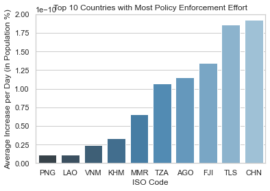

```python
sns.set(style='whitegrid')
ax = sns.barplot(x='iso_code', y="trends", data=policy_effort.head(10), palette="Blues_d")
ax.set(ylim=(0, 0.0000000002))
ax.set_title('Top 10 Countries with Most Policy Enforcement Effort')
ax.set_xlabel('ISO Code')
h = ax.set_ylabel('Average Increase per Day (in Population %)')
```

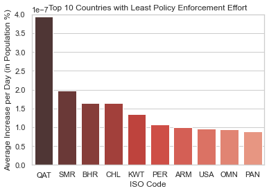

```python
sns.set(style='whitegrid')
ax = sns.barplot(x='iso_code', y="trends", data=policy_effort.tail(10).iloc[::-1], palette="Reds_d")
ax.set(ylim=(0, 0.0000004))
ax.set_title('Top 10 Countries with Least Policy Enforcement Effort')
ax.set_xlabel('ISO Code')
h = ax.set_ylabel('Average Increase per Day (in Population %)')
```

### 6.2 Use of Resources Effort

While policy effectiveness is a significant aspect of effort, it is not enough to cover the whole context needed to be considered to yield accurate observations. Countries have differing economic standings and these make a critical impact on the options and limitations they have in order to take measures against the coronavirus. To rank based on how well did a country make use of their resources at hand, I am going to utilize the stringency index and GDP per capita. The deviation from the linear trend of stringency indes versus GDP per capita will be ranked for calculating relative use of resources.

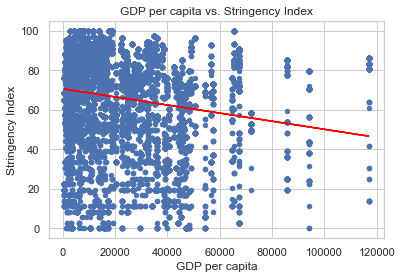

```python
%%capture output --no-display

u_df = df.dropna(subset=['stringency_index', 'gdp_per_capita'])

s_plot_resources = u_df.plot(kind='scatter', x='gdp_per_capita', y='stringency_index', title='')
m, b = np.polyfit(u_df.gdp_per_capita, u_df.stringency_index, 1)
plt.plot(u_df.gdp_per_capita, m*u_df.gdp_per_capita + b, color='red')
plt.title('GDP per capita vs. Stringency Index')
plt.xlabel('GDP per capita')
h = plt.ylabel('Stringency Index')
```

As a side observation, it is interesting to note that there appears to be a negative correlation between GDP per capita and the stringency index. This implies looser policies tend to be implemented by better-off nations. Of course, looser does not equate to less effective. This observation could have further ties with government form, for there are a far greater number of relatively less affluent countries with more central governments. This makes it possible for stricter policies to be implemented in a streamlined way.

```python
u_df['deviation_si'] = u_df['stringency_index']

for i, v in u_df.iterrows():
    actual = u_df.at[i, 'stringency_index']
    expected = m*v.gdp_per_capita + b
    u_df.at[i, 'deviation_si'] = actual - expected

cols = {'iso_code':u_df.iso_code, 'deviation_si':u_df['deviation_si']}
resources_effort = pd.DataFrame(cols).groupby('iso_code').first()

resources_effort['iso_code'] = resources_effort.index

resources_effort['ranking'] = resources_effort.deviation_si.rank()

# Order by rank
resources_effort = resources_effort.sort_values('deviation_si')

resources_effort
```

| iso_code | deviation_si | iso_code | ranking |
| --- | --- | --- | --- |
| TGO | -70.311520 | TGO | 1.0 |
| BFA | -70.255539 | BFA | 2.0 |
| SEN | -70.098326 | SEN | 3.0 |
| CMR | -69.915125 | CMR | 4.0 |
| KHM | -69.857739 | KHM | 5.0 |
| ... | ... | ... | ... |
| HTI | 5.664234 | HTI | 161.0 |
| FJI | 10.808340 | FJI | 162.0 |
| MDG | 12.095740 | MDG | 163.0 |
| LBY | 23.798504 | LBY | 164.0 |
| PRI | 30.094268 | PRI | 165.0 |

165 rows × 3 columns

Here are the top 10 countries that make the most and least effort in the use of resources and corresponding difference between the expected and actual stringency index.

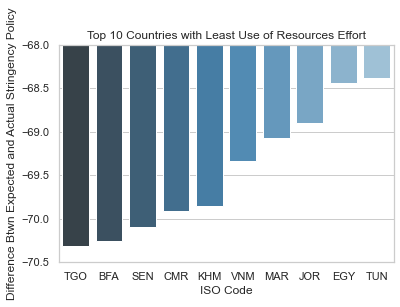

```python
sns.set(style='whitegrid')
ax = sns.barplot(x='iso_code', y="deviation_si", data=resources_effort.head(10), palette="Blues_d")
h = ax.set(ylim=(-70.5, -68))
h = ax.set_title('Top 10 Countries with Least Use of Resources Effort')
h = ax.set_xlabel('ISO Code')
h = ax.set_ylabel('Difference Btwn Expected and Actual Stringency Policy')
```

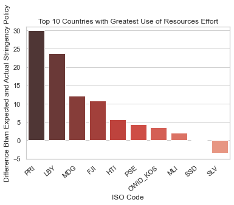

```python
sns.set(style='whitegrid')
ax = sns.barplot(x='iso_code', y="deviation_si", data=resources_effort.tail(10).iloc[::-1], palette="Reds_d")
h = ax.set(ylim=(-5, 31))
h = ax.set_title('Top 10 Countries with Greatest Use of Resources Effort')
h = ax.set_xlabel('ISO Code')
h = ax.set_ylabel('Difference Btwn Expected and Actual Stringency Policy')
h = ax.set_xticklabels(ax.get_xticklabels(), rotation=40, ha="right")
```

### 6.3 US Effort

Having ranked all countries to calculate the two efforts, I am now going to take a look at the US' efforts in particular.

```python
print(resources_effort[resources_effort.iso_code == 'USA'])
```

```
          deviation_si iso_code  ranking
iso_code
USA         -59.496673      USA     36.0
```

```python
print(policy_effort[policy_effort.iso_code == 'USA'])
```

```
    iso_code        trends  ranking
172      USA  9.625996e-08    173.0
```

## 7. Conclusion and Additional Resources

After analyzing the different trends of the coronavirus counts, then moving onto calculating and ordering countries by the efforts they are making, I was able to gain quantitative insight into two areas. With the raw counts, I was able to analyze world trends and find noticeable patterns based on groupings and relating the different statistics. The effort measurement indicated countries’ performances, providing insight into relative standings. There are undoubtably many things unknown about these "unprecedented times," but I hope the analysis of the counts that have been released thus far and the attempt to create a metric has given the reader a starting point for obtaining an eye for the bigger picture of the pandemic.  
If the reader is new to data science, I recommend getting started by checking out the following modules and practicing to use them. As I had been a newcomer to data science myself at the beginning of the CMSC320 course, I can confidently say that practice indeed makes perfect. Below are the tools that I have used the most throughout the course.

- [Pandas](https://pandas.pydata.org/)
- [NumPy](https://numpy.org/)
- [Matplotlib](https://matplotlib.org/)